# Questionnaire Report for Blacklip Abalone

(MERA version 4.1.1)

Adrian Hordyk (a.hordyk@oceans.ubc.ca)

2019-04-18

# 1 About this document

This is a prototype of an automatic report that documents how the user specified the operating model and their various justifications.

# 2 Introduction

1. Describe the history and current status of the fishery, including fleets, sectors, vessel types and practices/gear by vessel type, landing ports, economics/markets, whether targeted/bycatch, other stocks caught in the fishery.

[Mayfield et al. (2012)](https://drive.google.com/open?id=1IU8vpPbIznmpdUfPZB7jBdznQgvlcQRb) provided an overview of the development and history of the NSW abalone fishery. The following brief history of the fishery and summary of the management arrangements are based on the information in Mayfield et al. (2012).

The commercial fishery for blacklip abalone in NSW began in the late 1950s and early 1960s. The fishery is the smallest fishery for blacklip abalone in Australia, contributing about 2% of the national catch. Catches increased throughout the 1960s and reached a peak in the early 1970s.

A minimum legal length of 100 mm shell length (SL) was first introduced in 1973. Declining catch rates throughout the 1970s were a cause for concern, and access to the fishery was restricted in 1980 with the issue of 56 annually renewable non-transferable permits. Catch rates began to rebuild in the early 1980s, but began to decline again in the mid-1980s which led to the introduction of several management changes:

1. A series of size limit increases were implemented in the 1980s, from 108 mm in 1980, to 111 mm in 1986, and finally to 115 mm in 1987.
2. A recreational bag limit of 25 abalone per day per person was introduced.
3. To reduced effort, a two-for-one system was introduced in 1985 where new entrants to the fishery had to acquire two existing permits which were then consolidated into one new permit.
4. An annual individual quota system was introduced in 1989 to control the catches.

After 1985 the catches remained relatively stable until the early 2000s when the catch rate began to decline significantly. In these years the fishers often had difficulty catching the declining TAC and there were serious concerns about the status of the abalone stocks. The TAC was continually reduced through the mid- to late-2000s, declining to a total TAC of 75 t in 2008/2009 compared to the 650 t/year that was being caught in the early 1980s, and the 333 t TAC in 1999.

The NSW abalone fishery is managed with four Spatial Management Units (SMU). This questionnaire has been answered based on the overall NSW stock.

2. Describe the stock’s ecosystem functions, dependencies, and habitat types. Abalone are found in rocky reef habitat and play an important ecosystem role of stabilizing kelp forests. More information in the ecological role of abalone in the reef system of south-eastern Australia can be found in [Hamer et al. (20100](https://drive.google.com/open?id=1hp1x0vhHy4vUxvwcJkjZYibMQyxwic7r).
3. Provide all relevant reference materials, such as assessments, research, and other analysis.

The primary source of information for the current condition of the NSW abalone stock is: [Abalone Council of NSW, 2018, Assessment of abalone stocks in NSW: Submission to the TAC setting process for 2019, Sydney](https://drive.google.com/open?id=1mGULhG5WYQUWLlOeG4_zwaSgytbi3BPx).

Other reference materials are provided throughout the questionnaire.

# 3 Fishery Characteristics

## 3.1 Longevity

| Answered |
| --- |
| Very short-lived (5 < maximum age < 7) |
| Short-lived (7 < maximum age < 10) |
| Moderate life span (10 < maximum age < 20) |
| Moderately long-lived (20 < maximum age < 40) |
| Long-lived (40 < maximum age < 80) |
| Very long-lived (80 < maximum age < 160) |

Justification

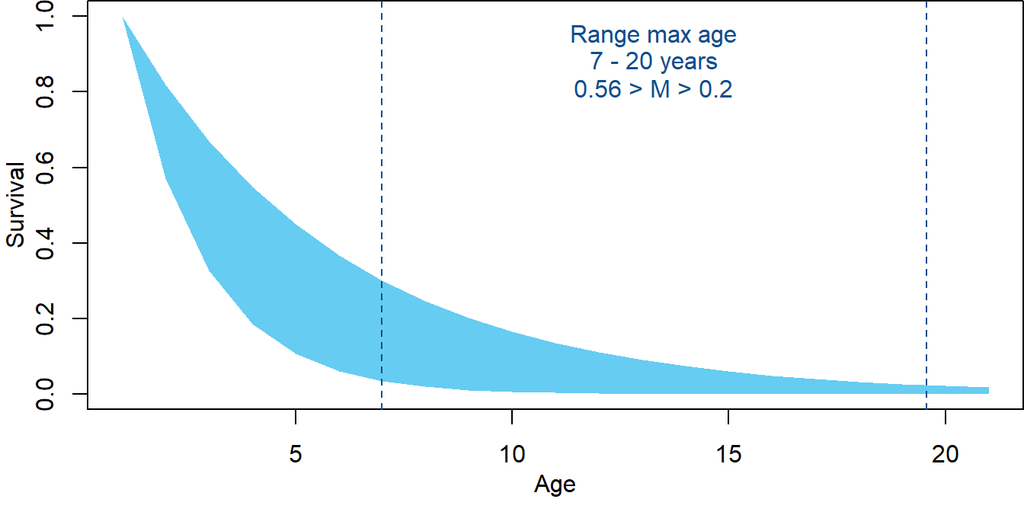

## 3.2 Stock depletion

| Answered |
| --- |
| Crashed (D < 0.05) |
| Very depleted (0.05 < D < 0.1) |
| Depleted (0.1 < D < 0.15) |
| Moderately depleted (0.15 < D < 0.3) |
| Healthy (0.3 < D < 0.5) |
| Underexploited (0.5 < D) |

Justification

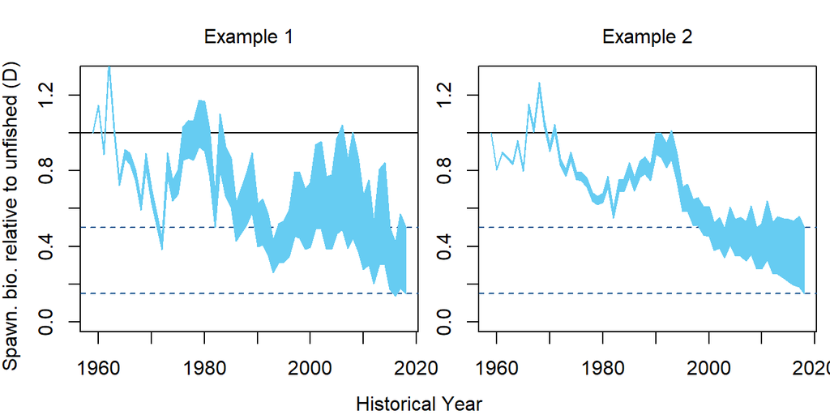

## 3.3 Resilence

| Answered |
| --- |
| Not resilient (steepness < 0.3) |
| Low resilience (0.3 < steepness < 0.5) |
| Moderate resilence (0.5 < steepness < 0.7) |
| Resilient (0.7 < steepness < 0.9) |
| Very Resilient (0.9 < steepness) |

Justification

No information was available on the steepness of the stock-recruitment relationship for the NSW stock. [McDonald et al (2001)](https://drive.google.com/open?id=1-FSMdV3Fpl6JAYnUg6EeoAdk1GL4_clR) report the assessment of a related species (paua; Haliotis iris) in New Zealand and provide Bayesian posteriors for steepness (h) will most values distributed between 0.6 and 0.9.  
In the absence of any other information, the range of 0.5 < steepness < 0.9 was selected.

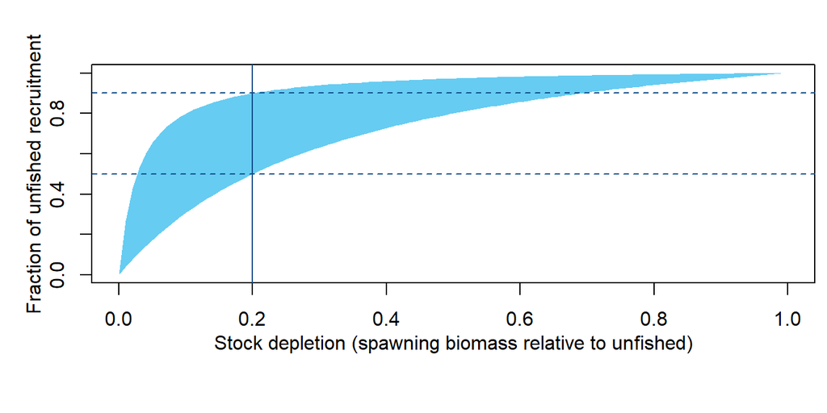

## 3.4 Historical effort pattern

| Answered |
| --- |
| Stable |
| Two-phase |
| Boom-bust |
| Gradual increases |
| Stable, recent increases |
| Stable, recent declines |

[output not shown]

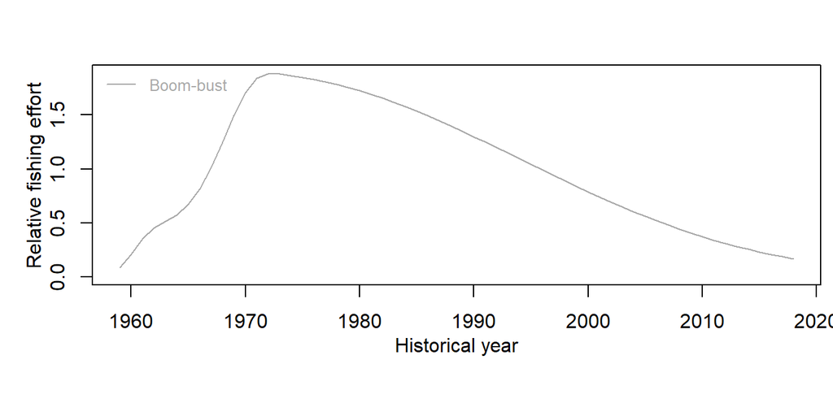

## 3.5 Inter-annual variability in historical effort

| Answered |
| --- |
| Not variable (less than 20% inter-annual change (IAC)) |
| Variable (maximum IAC between 20% to 50%) |
| Highly variable (maximum IAC between 50% and 100%) |

| Justification |
| --- |
| The commercial effort data in recent years (since 2000) has been relatively stable, with an average inter-annual variability in effort of 10% and a range of 1 to 30%. |

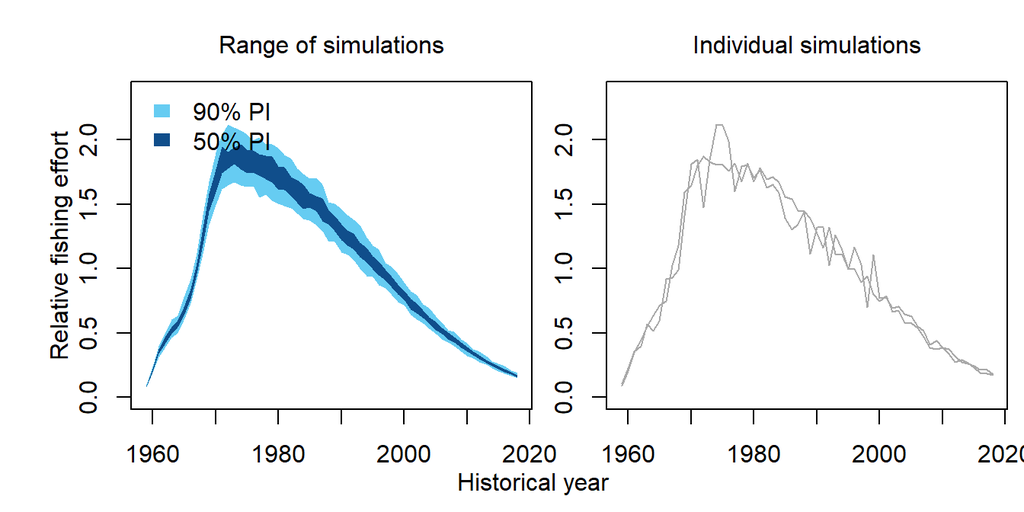

## 3.6 Historical fishing efficiency changes

| Answered |
| --- |
| Declining by 2-3% pa (halves every 25-35 years) |
| Declining by 1-2% pa (halves every 35-70 years) |
| Stable -1% to 1% pa (may halve/double every 70 years) |
| Increasing by 1-2% pa (doubles every 35-70 years) |
| Increasing by 2-3% pa (doubles every 25-35 years) |

Justification

No information is available on the changes in historical fishing efficiency.  
The abalone are harvested by hand by divers using either scuba gear or surface-air supply systems. Based on the increased technology in dive gear and navigation equipment since the 1960s, and the fact that diving for abalone requires skill I assume that declines in fishing efficiency over time are unlikely and may have increased by up to 2% per year since the fishery began in the 1960s.

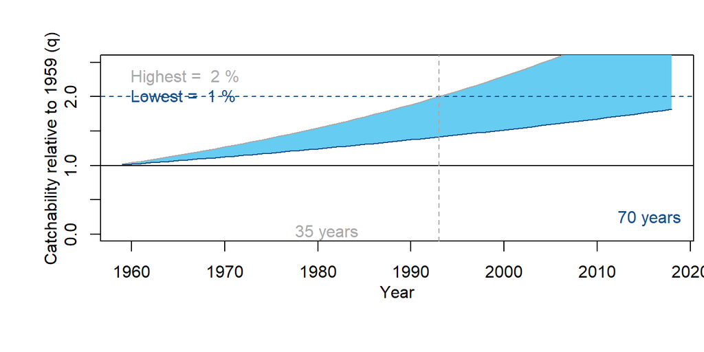

## 3.7 Future fishing efficiency changes

| Answered |
| --- |
| Declining by 2-3% pa (halves every 25-35 years) |
| Declining by 1-2% pa (halves every 35-70 years) |
| Stable -1% to 1% pa (may halve/double every 70 years) |
| Increasing by 1-2% pa (doubles every 35-70 years) |
| Increasing by 2-3% pa (doubles every 25-35 years) |

Justification

The NSW abalone fishery is limited entry and no new fishing permits are available. New divers can enter the fishery by purchasing permits from existing fishers. Significant improvements in dive technology and navigation equipment are considered unlikely. Based on these assumptions, fishing efficiency in the future is not expected to change significantly and has been limited here to an inter-annual change ranging from -1% to 1% pa.

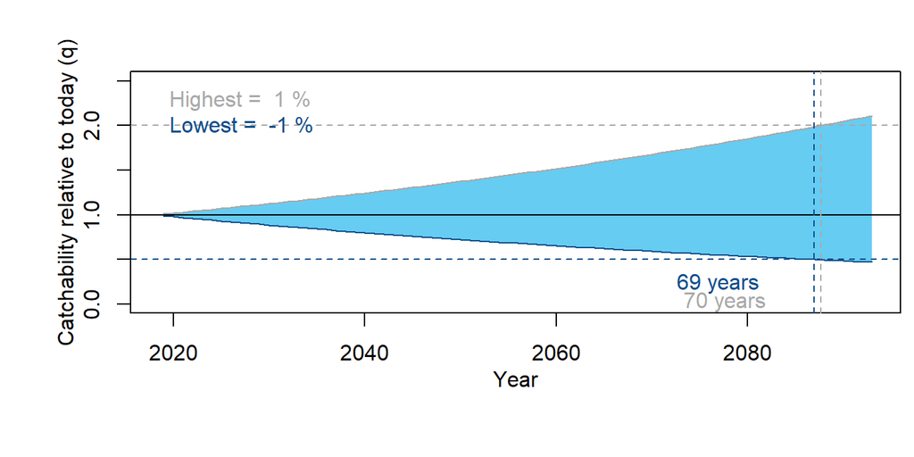

## 3.8 Length at maturity

| Answered |
| --- |
| Very small (0.4 < LM < 0.5) |
| Small (0.5 < LM < 0.6) |
| Moderate (0.6 < LM < 0.7) |
| Moderate to large (0.7 < LM < 0.8) |
| Large (0.8 < LM < 0.9) |

Justification

The [DPI abalone summary document](https://drive.google.com/open?id=1vfgViob8X2L9DHYs_tsiqyc9G0RRia9y) reports that blacklip abalone reach a maximum size of 220 mm shell length (SL) and reach maturity around 90 - 100 mm SL. Most abalone in the commericial fishery are < 145 mm, and the maximum observed length of 220 mm is likely an upwardly biased estimate for the average maximum size (Linf).  
[Prince et al (1988)](https://drive.google.com/open?id=1129-AbwNLcrCobvSwjAq97rDqtdM_obu) estimated asymptotic size of 140 mm and a length of maturity around 90 mm; a ratio of 0.64.  
Based on these values the values for the relative length of maturity for blacklip abalone were set to the range 0.5 - 0.7 Linf.

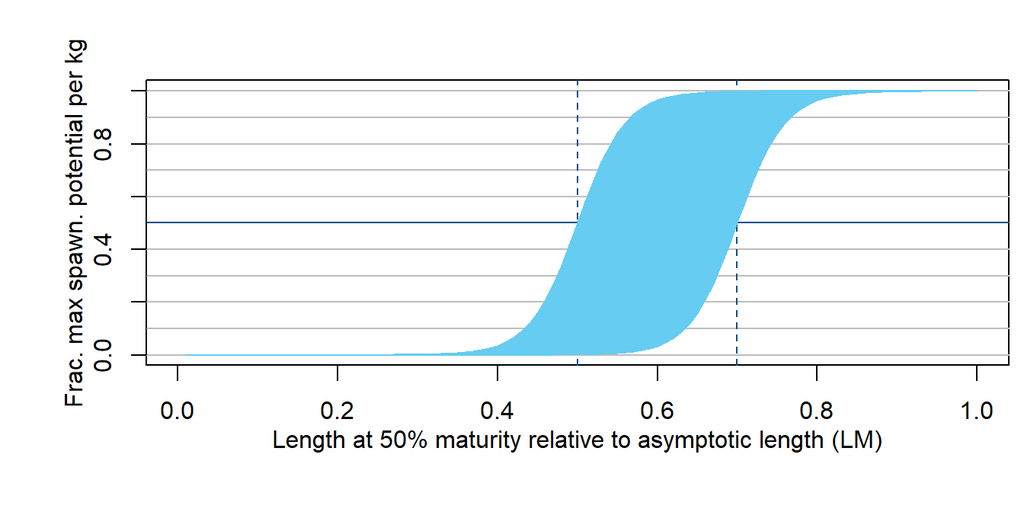

## 3.9 Selectivity of small fish

| Answered |
| --- |
| Very small (0.1 < S < 0.2) |
| Small (0.2 < S < 0.4) |
| Half asymptotic length (0.4 < S < 0.6) |
| Large (0.6 < S < 0.8) |
| Very large (0.8 < S < 0.9) |

Justification

The abalone fishery in NSW is managed with a legal minimum size limit of 117 mm for all regions, except for south of Wonboyn where it has been increased to 123 mm (representing about 22% of the abalone fishery) ([DPI Abalone Asssessment](https://drive.google.com/open?id=1kSIB-5QCptsyQEOl1kJzrR08nRzVjUMY)).  
Assuming an asymptotic shell length around 140 mm, this size limit suggests that the relative length of selectivity for small individuals is around 0.8 Linf.

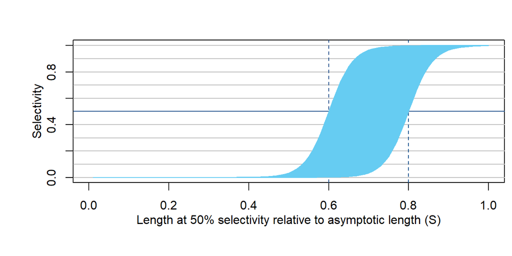

## 3.10 Selectivity of large fish

| Answered |
| --- |
| Asymptotic selectivity (SL = 1) |
| Declining selectivity with length (0.75 < SL < 1) |
| Dome-shaped selectivity (0.25 < SL < 0.75) |
| Strong dome-shaped selectivity (SL < 0.25) |

[output not shown]

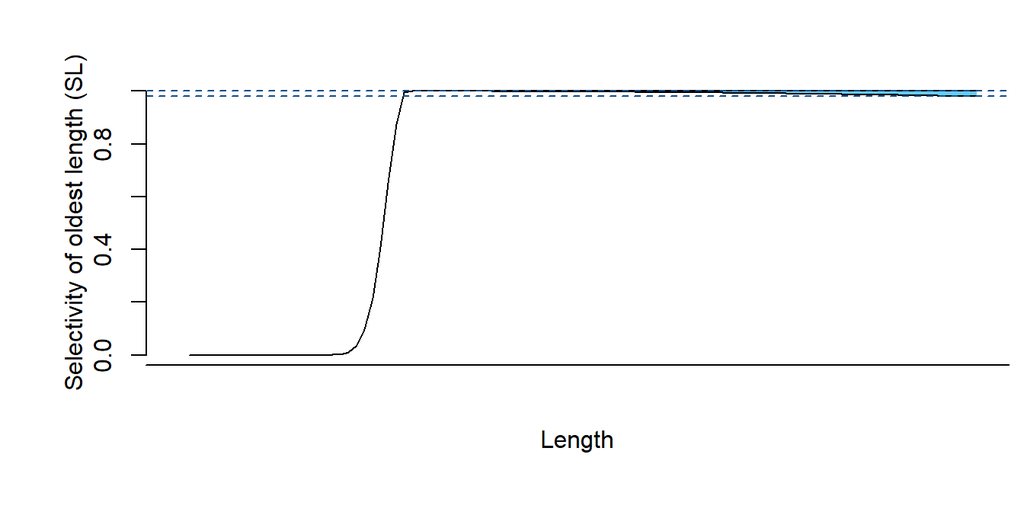

## 3.11 Discard rate

| Answered |
| --- |
| Low (DR < 1%) |
| Low - moderate (1% < DR < 10%) |
| Moderate (10% < DR < 30%) |
| Moderate - high (30% < DR < 50%) |
| High (50% < DR < 70%) |

[output not shown]

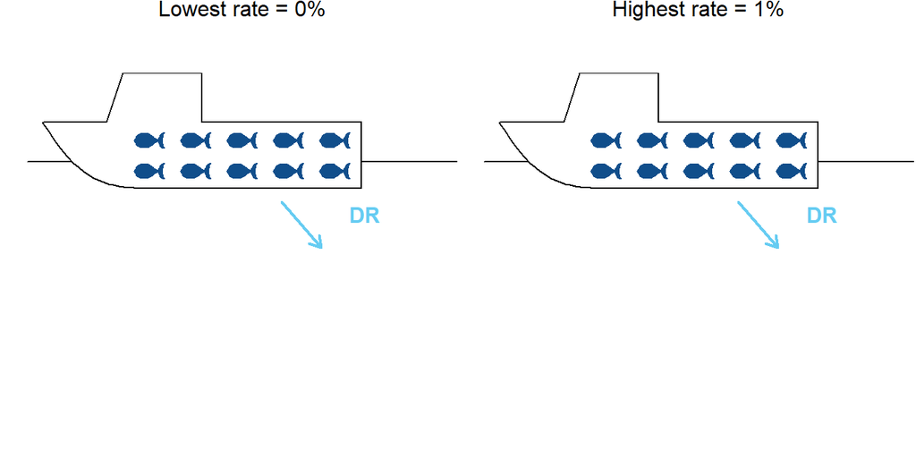

## 3.12 Post-release mortality rate

| Answered |
| --- |
| Low (PRM < 5%) |
| Low - moderate (5% < PRM < 25%) |
| Moderate (25% < PRM < 50%) |
| Moderate - high (50% < PRM < 75%) |
| High (75% < PRM < 95%) |
| Almost all die (95% < PRM < 100%) |

Justification

No information is available on the post-release mortality rate of blacklip abalone. Post-release mortality is likely to depend on the handling of the discarded abalone, and could range from very low if the abalone placed back on the reef, to considerably higher if they are thrown back into the water at the surface.  
Based on this uncertainty, the full range of options was selected for this question. However, discard rates of abalone are assumed to be very low, so this assumption is unlikely to have a significant impact on the results of the analysis.

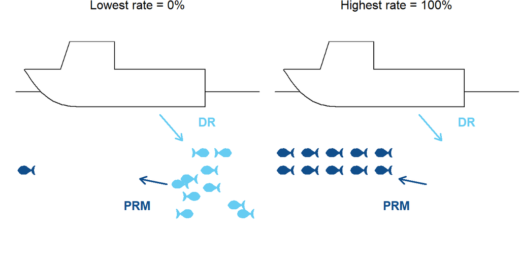

## 3.13 Recruitment variability

| Answered |
| --- |
| Very low (less than 10% inter-annual changes (IAC)) |
| Low (max IAC of between 20% and 60%) |
| Moderate (max IAC of between 60% and 120%) |
| High (max IAC of between 120% and 180%) |
| Very high (max IAC greater than 180%) |

Justification

[McShane and Smithh (1991)](https://drive.google.com/open?id=1D7FNkKBqZPnqPKO-Pn0ePbcdfE0iwpIT) studied recruitment dynamics of *Haliotis rubra* in south-east Australia and found evidence of large inter-annual variability in recruitment strength, even when the size of the adult stock remained relatively constant. They also note that recruitment variation in benthic invertebrates is typically very high and reliable stock-recruitment relationships are rarely observed for these species.  
Based on this information, the range for recruitment variability was set to ‘High’ and ‘Very high’.

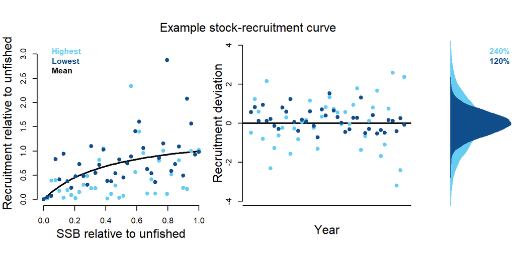

## 3.14 Size of an existing MPA

| Answered |
| --- |
| None |
| Small (A < 5%) |
| Small-moderate (5% < A < 10%) |
| Moderate (10% < A < 20%) |
| Large (20% < A < 30%) |
| Very large (30% < A < 40%) |
| Huge (40% < A < 50%) |

Justification

The abalone fishery is subject to a range of spatial closure from a network of marine protected areas that includes marine parks and other areas where commercial fishing is prohibited. A [map](https://drive.google.com/open?id=1llDIZMheXg7zVSgVR7j9DEeFPotSixu9) of the NSW coastline, taken from [The Fishery Management Strategy for the Abalone Fishery](https://drive.google.com/open?id=1B8IIEiJG3nFyvZNwfe8HROtNDhhr11ed), shows the fishery closure areas.  
No estimate of the proportion of total abalone habitat that is in the no-fishing areas is available. Based on the information shown in the map referred to above, the fraction of total habitat that is closed to fishing was assumed to be in the range of 10-20%.

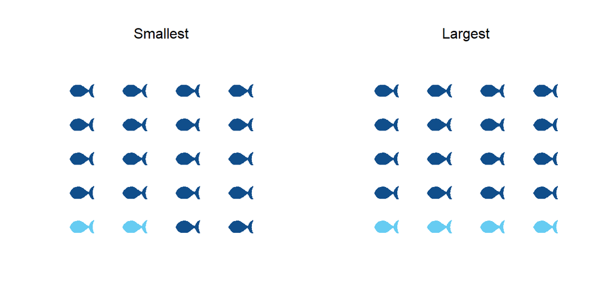

## 3.15 Spatial mixing (movement) in/out of existing MPA

| Answered |
| --- |
| Very low (P < 1%) |
| Low (1% < P < 5%) |
| Moderate (5% < P < 10%) |
| High (10% < P < 20%) |
| Fully mixed |

[output not shown]

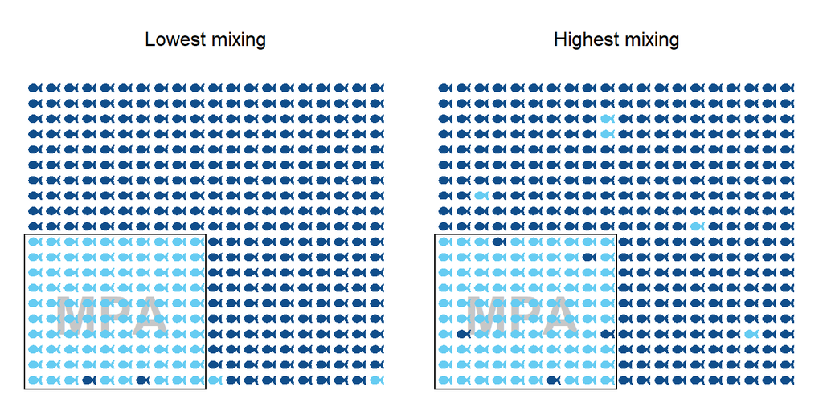

## 3.16 Size of a future potential MPA

| Answered |
| --- |
| None |
| Small (A < 5%) |
| Small-moderate (5% < A < 10%) |
| Moderate (10% < A < 20%) |
| Large (20% < A < 30%) |
| Very large (30% < A < 40%) |
| Huge (40% < A < 50%) |

| Justification |
| --- |
| To my knowledge, no further spatial closures are being considered for this fishery. |

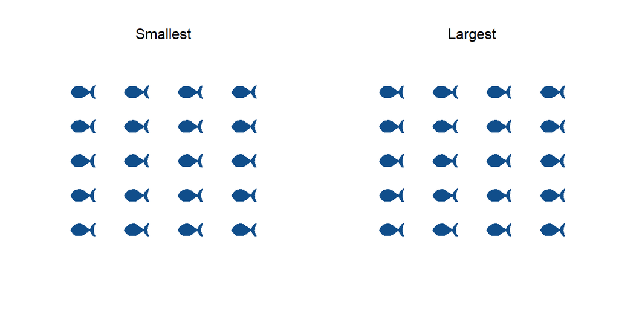

## 3.17 Spatial mixing (movement) in/out of future potential MPA

| Answered |
| --- |
| Very low (P < 1%) |
| Low (1% < P < 5%) |
| Moderate (5% < P < 10%) |
| High (10% < P < 20%) |
| Fully mixed |

| Justification |
| --- |
| No future MPA was assumed. Therefore movement rates were assumed to be fully mixed. |

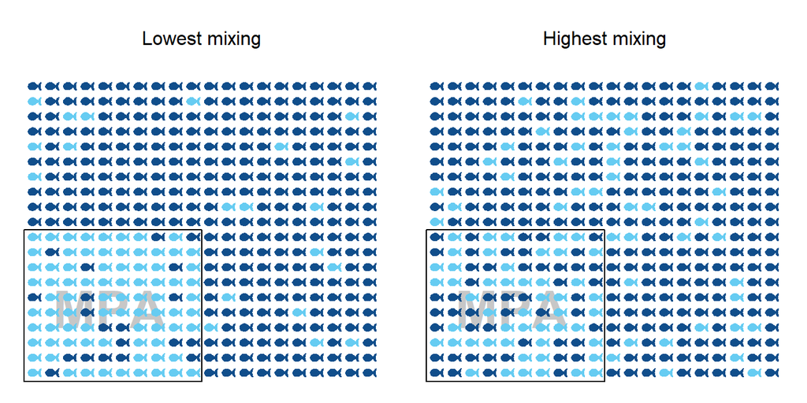

## 3.18 Initial stock depletion

| Answered |
| --- |
| Very low (0.1 < D1 < 0.15) |
| Low (0.15 < D1 < 0.3) |
| Moderate (0.3 < D < 0.5) |
| High (0.5 < D1) |
| Asymptotic unfished levels (D1 = 1) |

| Justification |
| --- |
| The stock is assumed to be at unfished levels in the 1960s. |

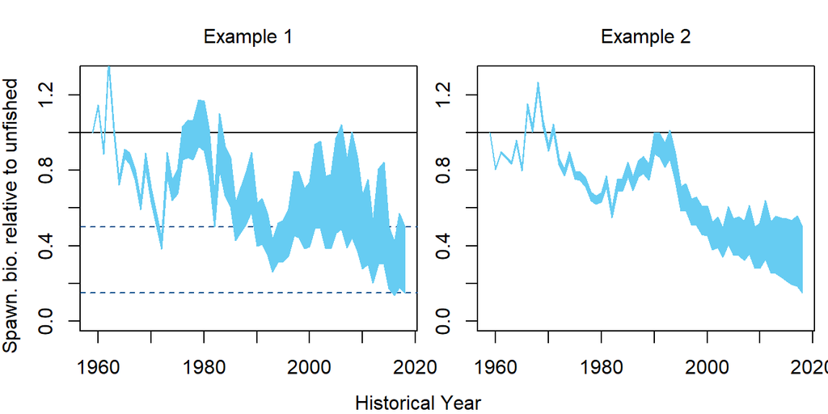

# 4 Management Characteristics

## 4.1 Types of fishery management that are possible

| Answered |
| --- |
| TAC (Total Allowable Catch): a catch limit |
| TAE (Total Allowable Effort): an effort limit |
| Size limit |
| Time-area closures (a marine reserve) |

Justification

1. Describe what, if any, current management measures are used to constrain catch/effort.  
The NSW abalone fishery is managed with commercial catch limits, size limits, limited access, and spatial closures. See [this report](https://drive.google.com/open?id=1kSIB-5QCptsyQEOl1kJzrR08nRzVjUMY) for more details.  
2. Describe historical management measures, if any.  
The TAC is adjusted annually, and the minimum size limit has been increased several times since it was introduced in 1973.  
3. Describe main strengths and weaknesses of current monitoring and enforcement capacity.  
The fishery is well managed with a combination of input and output controls that appear to be generally well enforced. High levels of illegal catch was a problem in the early stages of the fishery. Penalties for illegal fishing were increased in 2010. There have been reports of increased theft again in recent years.  
4. Describe and reference any legal/policy requirements for management, monitoring and enforcement.  
The NSW abalone fishery is managed in accordance with the Environmental Protection and Biodiversity Conservation Act 1999. See [this report](https://drive.google.com/open?id=1kSIB-5QCptsyQEOl1kJzrR08nRzVjUMY) for more details.

## 4.2 TAC offset: consistent overages/underages

| Answered |
| --- |
| Large underages (40% - 70% of recommended) |
| Underages (70% - 90% of recommended) |
| Slight underages (90% - 100% of recommended) |
| Taken exactly (95% - 105% of recommended) |
| Slight overages (100% - 110% of recommended) |
| Overages (110% - 150% of recommended) |
| Large overages (150% - 200% of recommended) |

[output not shown]

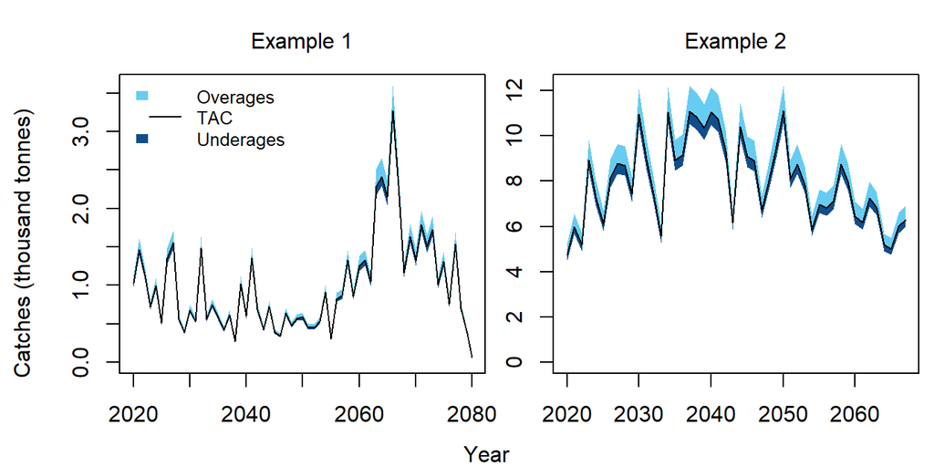

## 4.3 TAC implementation variability

| Answered |
| --- |
| Constant (V < 1%) |
| Not variable (1% < V < 5%) |
| Low variability (5% < V < 10%) |
| Variable (10% < V < 20%) |
| Highly variable (20% < V < 40%) |

| Justification |
| --- |
| There is no evidence to suggest that there is considerable inter-annual variation in the implementation of the TAC. |

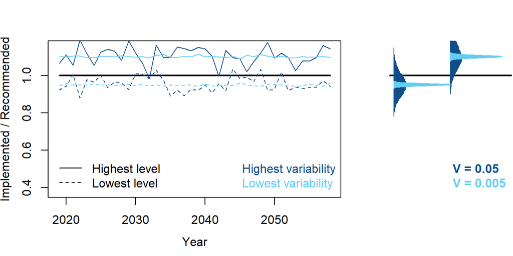

## 4.4 TAE offset: consistent overages/underages

| Answered |
| --- |
| Large underages (40% - 70% of recommended) |
| Underages (70% - 90% of recommended) |
| Slight underages (90% - 100% of recommended) |
| Taken exactly (95% - 105% of recommended) |
| Slight overages (100% - 110% of recommended) |
| Overages (110% - 150% of recommended) |
| Large overages (150% - 200% of recommended) |

| Justification |
| --- |
| The TAE offset was set to match the TAC, assuming in general that any effort controls would be well implemented, but allowing for a small amount of additional effort due to illegal fishing. |

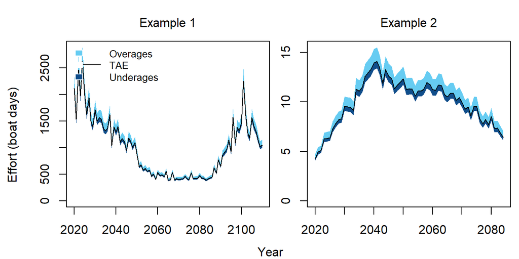

## 4.5 TAE implementation variability

| Answered |
| --- |
| Constant (V < 1%) |
| Not variable (1% < V < 5%) |
| Low variability (5% < V < 10%) |
| Variable (10% < V < 20%) |
| Highly variable (20% < V < 40%) |

| Justification |
| --- |
| The TAE implementation variability was matched to the TAC implementation variability. |

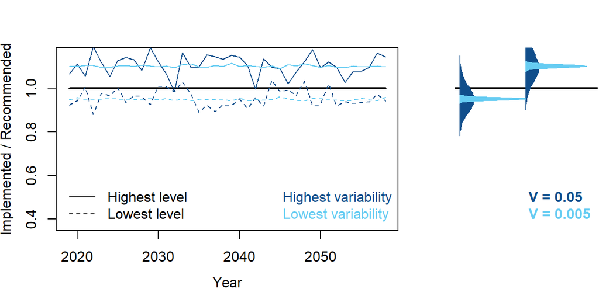

## 4.6 Size limit offset: consistent overages/underages

| Answered |
| --- |
| Much smaller (40% - 70% of recommended) |
| Smaller (70% - 90% of recommended) |
| Slightly smaller (90% - 100% of recommended) |
| Taken exactly (95% - 105% of recommended) |
| Slightly larger (100% - 110% of recommended) |
| Larger (110% - 150% of recommended) |
| Much larger (150% - 200% of recommended) |

[output not shown]

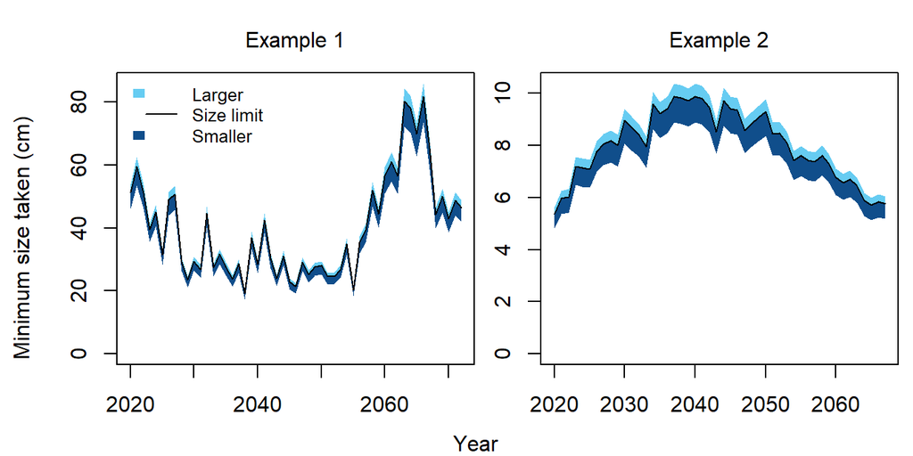

## 4.7 Size limit implementation variability

| Answered |
| --- |
| Constant (V < 1%) |
| Not variable (1% < V < 5%) |
| Low variability (5% < V < 10%) |
| Variable (10% < V < 20%) |
| Highly variable (20% < V < 40%) |

| Justification |
| --- |
| Implementation of the size limits was assumed to be stable over time. |

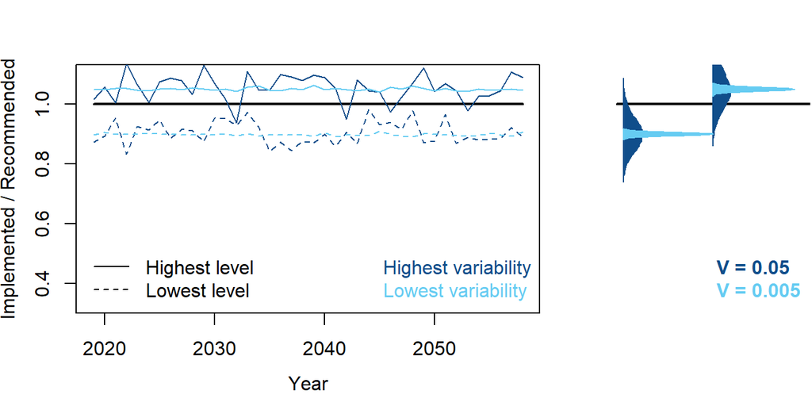

# 5 Data Characteristics

## 5.1 Available data types

| Answered |
| --- |
| Historical annual catches (from unfished) |
| Recent annual catches (at least 5 recent years) |
| Historical relative abundance index (from unfished) |
| Recent relative abundance index (at least 5 recent years) |
| Fishing effort |
| Size composition (length samples) |
| Age composition (age samples) |
| Growth (growth parameters) |
| Absolute biomass survey |

Justification

The available data, details of the data analyse, and the evaluation of the NSW abalone stocks are summarized in the [Abalone Council of NSW Report](https://drive.google.com/open?id=1mGULhG5WYQUWLlOeG4_zwaSgytbi3BPx).  
Primary performance indicators for this fishery are the standardized catch rate and the average weight of abalone from logbook reporting, and an annual index of biomass calculated from GPS logger data. Secondary performance indicators include measures of catch and effort from logbooks and length of abalone from measuring loggers.

## 5.2 Catch reporting bias

| Answered |
| --- |
| Strong under-reporting (30% - 50%) |
| Under-reporting (10% - 30%) |
| Slight under-reporting (less than 10%) |
| Reported accurately (+/- 5%) |
| Slight over-reporting (less than 10%) |

[output not shown]

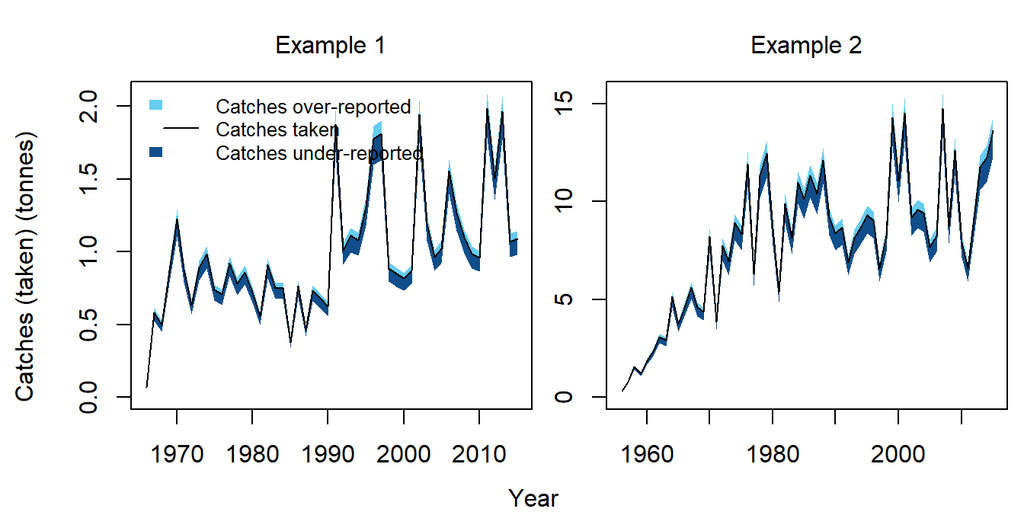

## 5.3 Hyperstability in indices

| Answered |
| --- |
| Strong hyperdepletion (2 < Beta < 3) |
| Hyperdepletion (1.25 < Beta < 2) |
| Proportional (0.8 < Beta < 1.25) |
| Hyperstability (0.5 < Beta < 0.8) |
| Strong hyperstability (0.33 < Beta < 0.5) |

[output not shown]

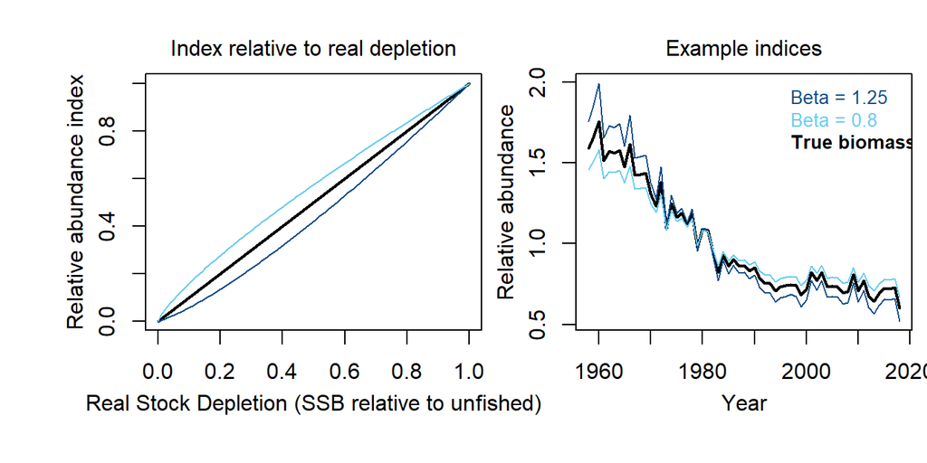

## 5.4 Available data types

| Answered |
| --- |
| Perfect |
| Good (accurate and precise) |
| Data moderate (some what inaccurate and imprecise) |
| Data poor (inaccurate and imprecise) |

[output not shown]

# 6 Version Notes

The package is subject to ongoing testing. If you find a bug or a problem please send a report to t.carruthers@oceans.ubc.ca so that it can be fixed!

User-2019-04-18-14:15:30

copyright (c) NRDC 2019